# 基于信用卡数据算法对比

中央财经大学 王思雨

2018-01-12

# 一、台湾信贷研究目的与问题

## 1.1 基于聚类算法

信贷数据将这30000条信贷用户记录分为两类：下一月份违约的用“1”标识。以及下一月份未违约的用“0”标识。该数据集的属性信息以及变量描述如表1-1所示，表中给定的是变量名称，变量说明，变量类型和取值范围等。

$~~~~~~~~~~~~~~~~~~~~~~~~~~~~~~~~~~~~~~~~~~~~~~~~~~~~~~~~~~~~~~$表1-1 属性变量说明表

| 变量名 | 变量说明 | 变量类型 | 取值范围 |
| --- | --- | --- | --- |
| X1 | 给定额度 | 数值型 | 1万-100万 |
| X2 | 性别 | 分类型 | 1：男，2：女 |
| X3 | 教育水平 | 分类型 | 1:graduate;2:university;3:high school;4:others |
| X4 | 婚姻状况 | 分类型 | 1:married;2:single;3:others |
| X5 | 年龄 | 数值型 | 21-79 |
| X6-X11 | 还款状态 | 数值型 | <0:按时还款，>0:超期相应月数还款 |
| X12-X17 | 票据金额 | 数值型 | X12表示2015-09，以此类推 |
| X18-X23 | 先前付款额 | 数值型 | X18表示2015-09，以此类推 |
| Y | 是否违约 | 分类型 | 0：未违约，1：违约 |

# 三、聚类算法与分类算法工具包载入

载入与本次试验相关的数据处理包’reshape2’,‘dplyr’,‘pryr’等,绘图包’ggplot2’,‘DiagrammeR’等，机器学习包’caret’,’xgboost’等以及性能测试包’pryr’等。由于本次试验需要对比各种机器学习算法的ROC曲线以及AUC值，所以进行了pROC的调用。

```r
#首先需要进行xgboost包的安装，只需在R中运行install.packages(‘xgboost’)即可。
library(xgboost)      #导入极限梯度下降法包
library(caret)
library(ggplot2)      #绘图包
library(DiagrammeR)
library(reshape2)     #数据处理包
library(dplyr)
library(pryr)
library(pROC)         #ROC曲线包
library(plyr)
library(showtext)     #使作图的字体更加丰富
library(RColorBrewer) #增加调色板
library(randomForest) #加载随机森林包
library(pryr)         #加载性能测试包
library(adabag)       #加载GBDT梯度提升树包
library(xgboost)      #加载XGBoost提升树包
library(DiagrammeR)
library(reshape2)
library(dbscan)
library(fpc)
library(sparcl)
```

# 四、台湾信贷数据可视化分析

## 4.1信贷数据预处理

```r
#数据预处理
#数据说明
taiwan<- read.csv("D:/bigdatahw/算法/作业/card1.csv",head=TRUE,sep=',') #读取台湾信用数据
taiwan$SEX<-as.factor(taiwan$SEX)
taiwan$EDUCATION<-as.factor(taiwan$EDUCATION)
taiwan$MARRIAGE<-as.factor(taiwan$MARRIAGE)
names(taiwan)[25]="default"              #重命名因变量
taiwan$default<-as.factor(taiwan$default)

levels(taiwan$SEX)=list(M="1",F="2")     #进行重命名等级
levels(taiwan$EDUCATION)=list(others="0",graduate="1",university="2", highschool="3",others="4",others="5",others="6")
levels(taiwan$MARRIAGE)=list(married="1", single="2",others="3",others="0")
levels(taiwan$default)=list(T="1", F="0")
```

## 4.2信贷数据描述性分析

### 4.2.1教育状况与违约占比性别分面风玫瑰图

从图中可以看出，不管是男性还是女性，信贷用户中大学毕业生人数比较多，其次是研究生。其他学历人数较少，还可以看出男性的信贷违约人数要少于女性，说明女性更容易违约。在途中还可以看出随着学历的逐渐上升，违约状况也有所改观，说明教育水平会提升信用状况。

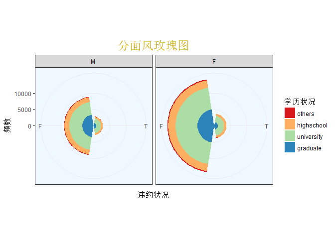

```r
label<-c("others","highschool","university","graduate")
taiwan$EDUCATION<- ordered(taiwan$EDUCATION, levels = label)
ggplot(taiwan,aes(x=default,fill=EDUCATION))+
  geom_bar()+coord_polar(theta = 'x')+
  scale_fill_brewer(palette='Spectral')+facet_wrap(~SEX)+theme_bw()+
  labs(x="违约状况",y="频数",fill="学历状况",title='分面风玫瑰图')+
  scale_x_discrete()+coord_polar(theta="x")+
  theme(plot.title = element_text(hjust =
        0.5,family="myFont",size=18,color="gold3"),
        panel.background=element_rect(fill='aliceblue'))
```

### 4.2.2违约与年龄分布直方图

根据所受教育水平的不同，违约状况的的年龄分布也有所不同，在学历为其他的用户中违约的年龄分布比较均匀，在高中毕业的水平下，总体的年龄分布比较均匀，违约人的年龄分布也是比较均匀的，在大学的教育水平下，年龄分布比较不均匀，整体成右偏分布，而违约人的年龄分布峰较低，比较平缓。在研究生阶段的的年龄分布峰较高，成尖峰分布，且有右偏拖尾。整体的违约比率较低，分布比较平缓。

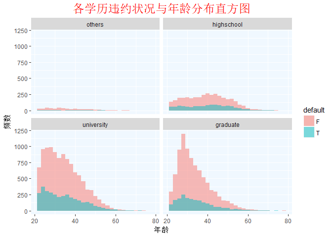

```r
label<-c("F","T")
taiwan$default<- ordered(taiwan$default, levels = label)
p<-ggplot(taiwan,aes(x=AGE,fill=default))
p+geom_histogram(position="identity",alpha=0.5)+
  ggtitle('各学历违约状况与年龄分布直方图')+
  theme(plot.title = element_text(hjust =
        0.5,family="myFont",size=18,color="red"),
        panel.background=element_rect(fill='aliceblue')) +
  xlab("年龄") +ylab("频数")+
  facet_wrap(~EDUCATION)
```

### 4.2.3银行给定额度与违约箱线图

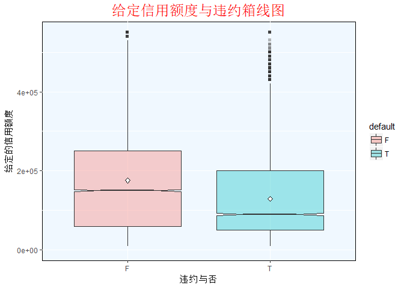

```r
ggplot(taiwan,aes(x=default,y=LIMIT_BAL,fill=default))+
  geom_boxplot(outlier.size=1.5, outlier.shape=15,notch=TRUE,alpha=.35)+
  stat_summary (fun.y="mean",geom="point",shape=23,size=2,fill="white")+
  xlab("违约与否") + ylab("给定的信用额度")+
  ggtitle('给定信用额度与违约箱线图')+ylim(0,550000)+
  theme(plot.title = element_text(hjust = 0.5,
        family="myFont",size=18,color="red"),
        panel.background=element_rect(fill='aliceblue',color='black'))
```

### 4.2.4婚姻状况与违约之间关系

在图中可以看出婚姻状况与违约之间的关系，数量关系没有描述统计的必要，主要进行百分比之间的转化，在分面饼状图中可以清楚的看出，婚姻状况对违约并没有很大的影响，主要的影响是比较细微的，单身的违约概率是比较小的，大约占到总体的1/5左右，而已婚和其他的状况违约概率是几乎一样的，都占各自总体的1/4左右。

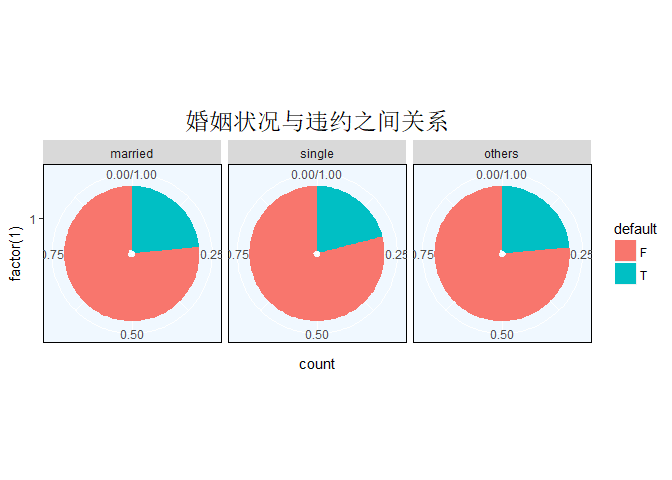

```r
ggplot(taiwan,aes(x=factor(1),fill=default))+
  geom_bar(aes(fill=default),position="fill")+
  coord_polar(theta="y")+
  ggtitle('婚姻状况与违约之间关系')+
  theme(plot.title = element_text(hjust =
       0.5,family="myFont",size=18,color="black"),
       panel.background=element_rect(fill='aliceblue',color='black'))+
       facet_wrap(~MARRIAGE)
```

### 4.2.5教育与违约关系

在教育水平与违约状况环形图中，也可以看到，违约占比较高的教育水平为高中阶段，其次是大学，然后是研究生，相比之下，其他的教育水平违约占比较低，因此我们也可以大胆的推断other是一种更高的教育水平。有可能是博士阶段。各个学历水平的违约率都没超过1/4，other更是小于1/10。

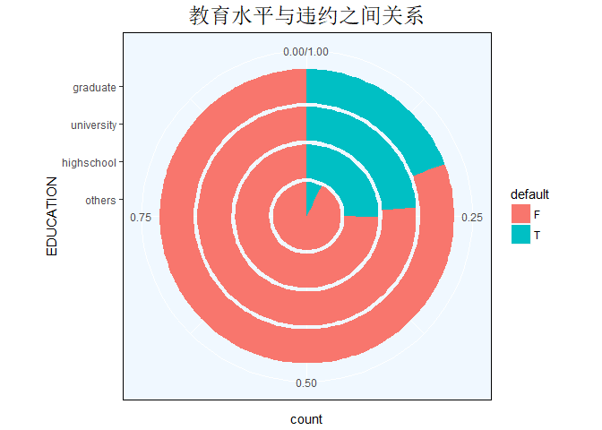

```r
ggplot(taiwan, aes(EDUCATION))+geom_bar(aes(fill=default),position="fill")+
  coord_polar(theta = "y")+ggtitle('教育水平与违约之间关系')+
  theme(plot.title = element_text(hjust =
        0.5,family="myFont",size=18,color="black"),
        panel.background=element_rect(fill='aliceblue',color='black'))
```

### 4.2.6年龄与给定额度关系

我们筛选的是具有违约状况的信用记录来进行分析。由于点的数量太多，因此绘制了分箱密度估计图，横坐标是违约用户的年龄，纵坐标是给定额度的对数值。来分析对于违约的用户，什么样的年龄和给定额度下违约的人数较多，可以在图中看到，红色区域对应着25岁给定额度为10的人数违约较多，其次还有25岁给定额度为11左右的人。因此银行在分配额度是应该注意这一点，利用密度图来规避风险，尽量少分配给25年龄段更多的信用。还可以看出给定额度与年龄的关系并不大，年龄小一样可以获得较高额度。

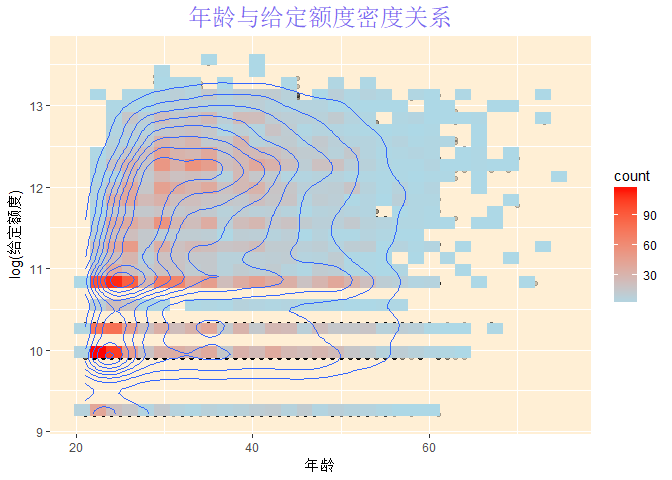

```r
taiwan<-taiwan[which(taiwan$default=='T'),]
p=ggplot(taiwan,aes(x=AGE,y=log(LIMIT_BAL)))
#默认等高线图进行分箱化处理
p+geom_point(alpha=0.2)+stat_bin2d()+
  scale_fill_gradient(low="lightblue",high="red")+stat_density2d()+
  theme(plot.title = element_text(hjust =
        0.5,family="myFont",size=18,color="slateblue2"),
        panel.background=element_rect(fill='papayawhip'))+
  labs(x='年龄',y='log(给定额度)',title='年龄与给定额度密度关系')
```

# 五、基于台湾信贷数据的聚类方法比较与分析

## 5.1 数据预处理

```r
setwd('D:/bigdatahw/算法/作业')   #设置工作路径
taiwan=read.csv("card1.csv")
names(taiwan)[25]="default"       #重命名因变量
#特征变量性别、年龄、教育程度以及下月是否违约转换为因子变量
taiwan$default<- as.factor(taiwan$default)
taiwan$SEX <- as.factor(taiwan$SEX)
taiwan$EDUCATION <- as.factor(taiwan$EDUCATION)
taiwan$MARRIAGE <- as.factor(taiwan$MARRIAGE)
summary(taiwan)
```

```
##        ID          LIMIT_BAL       SEX       EDUCATION MARRIAGE
##  Min.   :    1   Min.   :  10000   1:11888   0:   14   0:   54
##  1st Qu.: 7501   1st Qu.:  50000   2:18112   1:10585   1:13659
##  Median :15000   Median : 140000             2:14030   2:15964
##  Mean   :15000   Mean   : 167484             3: 4917   3:  323
##  3rd Qu.:22500   3rd Qu.: 240000             4:  123
##  Max.   :30000   Max.   :1000000             5:  280
##                                              6:   51
##       AGE            PAY_0             PAY_2             PAY_3
##  Min.   :21.00   Min.   :-2.0000   Min.   :-2.0000   Min.   :-2.0000
##  1st Qu.:28.00   1st Qu.:-1.0000   1st Qu.:-1.0000   1st Qu.:-1.0000
##  Median :34.00   Median : 0.0000   Median : 0.0000   Median : 0.0000
##  Mean   :35.49   Mean   :-0.0167   Mean   :-0.1338   Mean   :-0.1662
##  3rd Qu.:41.00   3rd Qu.: 0.0000   3rd Qu.: 0.0000   3rd Qu.: 0.0000
##  Max.   :79.00   Max.   : 8.0000   Max.   : 8.0000   Max.   : 8.0000
##
##      PAY_4             PAY_5             PAY_6           BILL_AMT1
##  Min.   :-2.0000   Min.   :-2.0000   Min.   :-2.0000   Min.   :-165580
##  1st Qu.:-1.0000   1st Qu.:-1.0000   1st Qu.:-1.0000   1st Qu.:   3559
##  Median : 0.0000   Median : 0.0000   Median : 0.0000   Median :  22382
##  Mean   :-0.2207   Mean   :-0.2662   Mean   :-0.2911   Mean   :  51223
##  3rd Qu.: 0.0000   3rd Qu.: 0.0000   3rd Qu.: 0.0000   3rd Qu.:  67091
##  Max.   : 8.0000   Max.   : 8.0000   Max.   : 8.0000   Max.   : 964511
##
##    BILL_AMT2        BILL_AMT3         BILL_AMT4         BILL_AMT5
##  Min.   :-69777   Min.   :-157264   Min.   :-170000   Min.   :-81334
##  1st Qu.:  2985   1st Qu.:   2666   1st Qu.:   2327   1st Qu.:  1763
##  Median : 21200   Median :  20089   Median :  19052   Median : 18105
##  Mean   : 49179   Mean   :  47013   Mean   :  43263   Mean   : 40311
##  3rd Qu.: 64006   3rd Qu.:  60165   3rd Qu.:  54506   3rd Qu.: 50191
##  Max.   :983931   Max.   :1664089   Max.   : 891586   Max.   :927171
##
##    BILL_AMT6          PAY_AMT1         PAY_AMT2          PAY_AMT3
##  Min.   :-339603   Min.   :     0   Min.   :      0   Min.   :     0
##  1st Qu.:   1256   1st Qu.:  1000   1st Qu.:    833   1st Qu.:   390
##  Median :  17071   Median :  2100   Median :   2009   Median :  1800
##  Mean   :  38872   Mean   :  5664   Mean   :   5921   Mean   :  5226
##  3rd Qu.:  49198   3rd Qu.:  5006   3rd Qu.:   5000   3rd Qu.:  4505
##  Max.   : 961664   Max.   :873552   Max.   :1684259   Max.   :896040
##
##     PAY_AMT4         PAY_AMT5           PAY_AMT6        default
##  Min.   :     0   Min.   :     0.0   Min.   :     0.0   0:23364
##  1st Qu.:   296   1st Qu.:   252.5   1st Qu.:   117.8   1: 6636
##  Median :  1500   Median :  1500.0   Median :  1500.0
##  Mean   :  4826   Mean   :  4799.4   Mean   :  5215.5
##  3rd Qu.:  4013   3rd Qu.:  4031.5   3rd Qu.:  4000.0
##  Max.   :621000   Max.   :426529.0   Max.   :528666.0
##
```

```r
## 定义标准化函数，将原始数据压缩到0-1之间，同一量纲
myfun=function(x)
{
  m1=max(x)
  m2=min(x)
  y=(x-m1)/(m2-m1)
  return(y)
}
## 抽取部分样本作为建模数据，并进行标准化处理
set.seed(123)
s=sample(1:dim(taiwan)[1],500)
taiwan_num=apply(taiwan[s,c(2,6:24)],2,myfun)    #聚类数值数据
taiwan_char_num=cbind(taiwan_num,taiwan[s,3:5])  #聚类数值+分类数据
```

## 5.2AGNES算法层次聚类

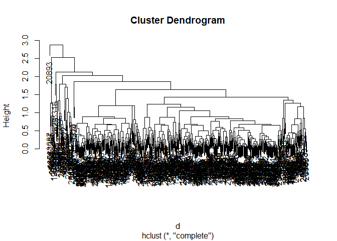

```r
## 由于聚类分析是无监督分类，无法知道聚类结果到底是属于哪一类。
## 所以要定义函数变换混淆矩阵，使得对角线上的元素最大，然后输
## 出混淆矩阵，以便确定聚类结果分别属于哪一个类。定义函数找出
## 对角线上数量最大的矩阵
myfun1=function(a,b)
{
  table<-table(a, b)
  Accuracy1=table[1,1]+table[2,2]
  Accuracy2=table[1,2]+table[2,1]
  if(Accuracy1>Accuracy2){
    confusion<-table(a,b)
    rownames(confusion)<-c('未违约','违约')
    colnames(confusion)<-c('未违约','违约')
    return(confusion)}
  else{ label<-c("2","1")
        b<- ordered(b, levels = label)
        confusion<-table(a,b)
        rownames(confusion)<-c('未违约','违约')
        colnames(confusion)<-c('未违约','违约')
        return(confusion)}
}
d<-dist(taiwan_num)               #计算样本之间的欧式距离
hc<-hclust(d, method="complete")  #根据距离进行聚类,类间距离定义为全连接
plot(hc)                          #显示聚类结果图
```

```r
hccut<-cutree(hc,k=2)             #将类别数定为2
myfun1(taiwan[s,]$default, hccut) #需要变0-1
```

```
##         b
## a        未违约 违约
##   未违约    381    1
##   违约      118    0
```

## 5.3Kmeans聚类

```r
kc<-kmeans(taiwan_num,2)                 #k均值聚类将样本聚成2类
myfun1(taiwan[s,]$default, kc$cluster)
```

```
##         b
## a        未违约 违约
##   未违约    271  111
##   违约       58   60
```

```r
#显示混淆矩阵，可以调整以下顺序就会不同了，遍历一下
```